# Procesado de Señales e Imágenes Médicas

Ingeniería Biomédica

Ph.D. Pablo Eduardo Caicedo Rodríguez

2024-01-22

# Procesamiento de imágenes

## Relationships between pixels – Neighborhood

**Neighborhood**

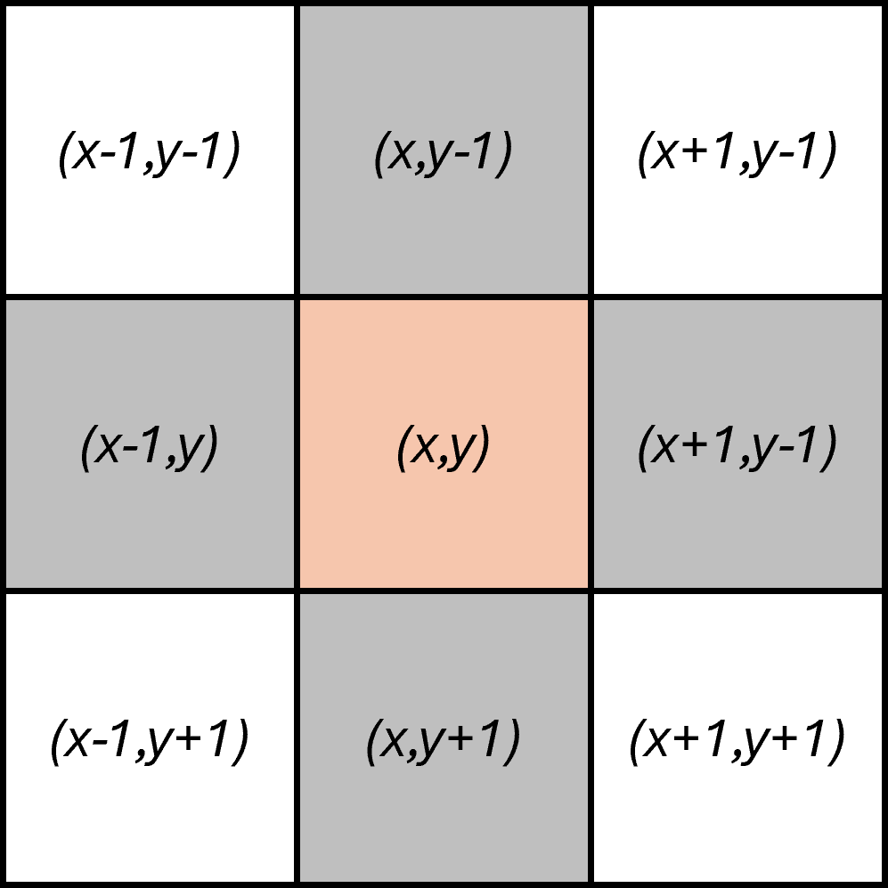

N4-$N_4\left(p\right)$

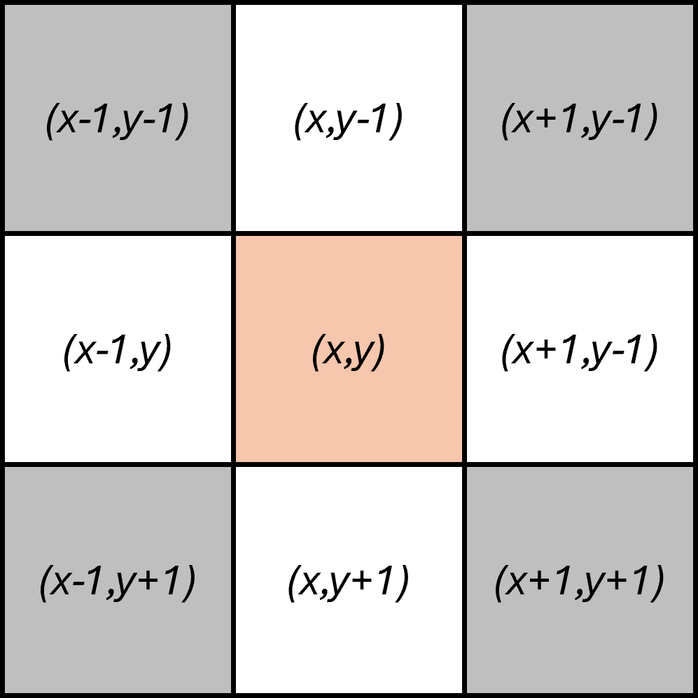

ND-$N_D\left(p\right)$

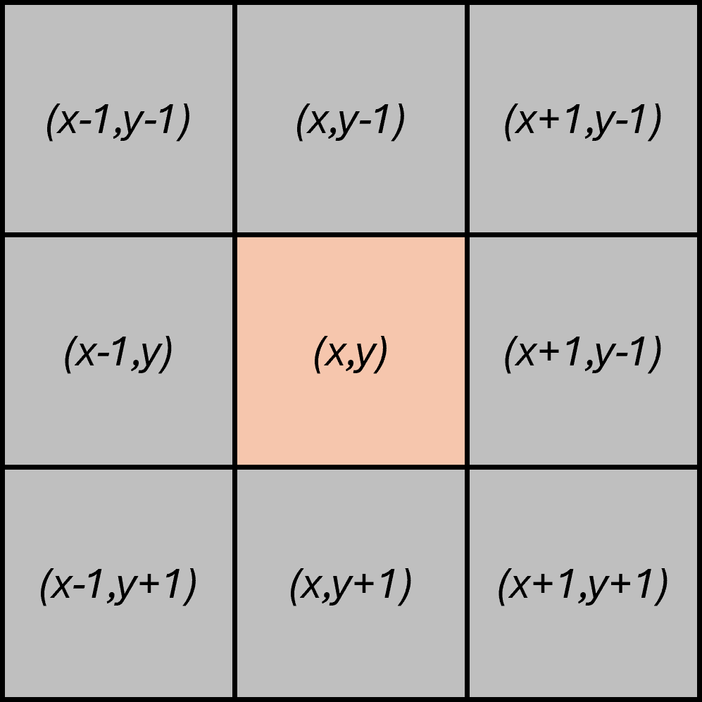

N8-$N_8\left(p\right)$

Figura 1: Neighborhoods

## Relationships between pixels – Adjacency

**Rules for adjecency**

- 4-Adjecncy: Two pixels p and q with values from V are 4-adjacent if q is in the set $N_4\left(p\right)$
- 8-adjacency. Two pixels p and q with values from V are 8-adjacent if q is in the set $N_8\left(p\right)$
- m-adjacency (also called mixed adjacency). Two pixels p and q with values from V are m-adjacent if:
  - q is in $N_4\left(p\right)$.
  - q is in $N_D\left(p\right)$ and the set $N_4\left(p\right) \cap N_4\left(q\right)$ has no pixels whose values are from V.

## Relationships between pixels

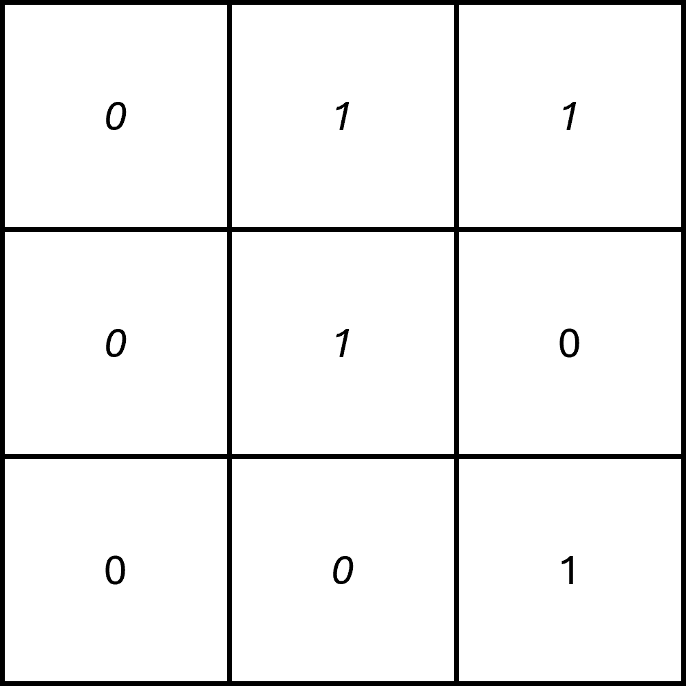

Adjacency

## Relationships between pixels

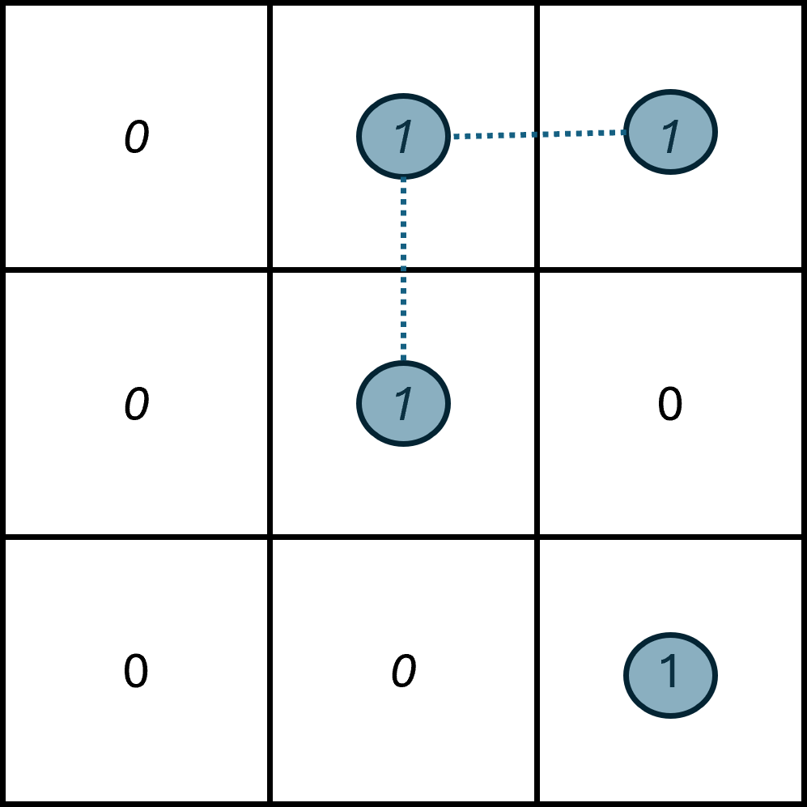

A4

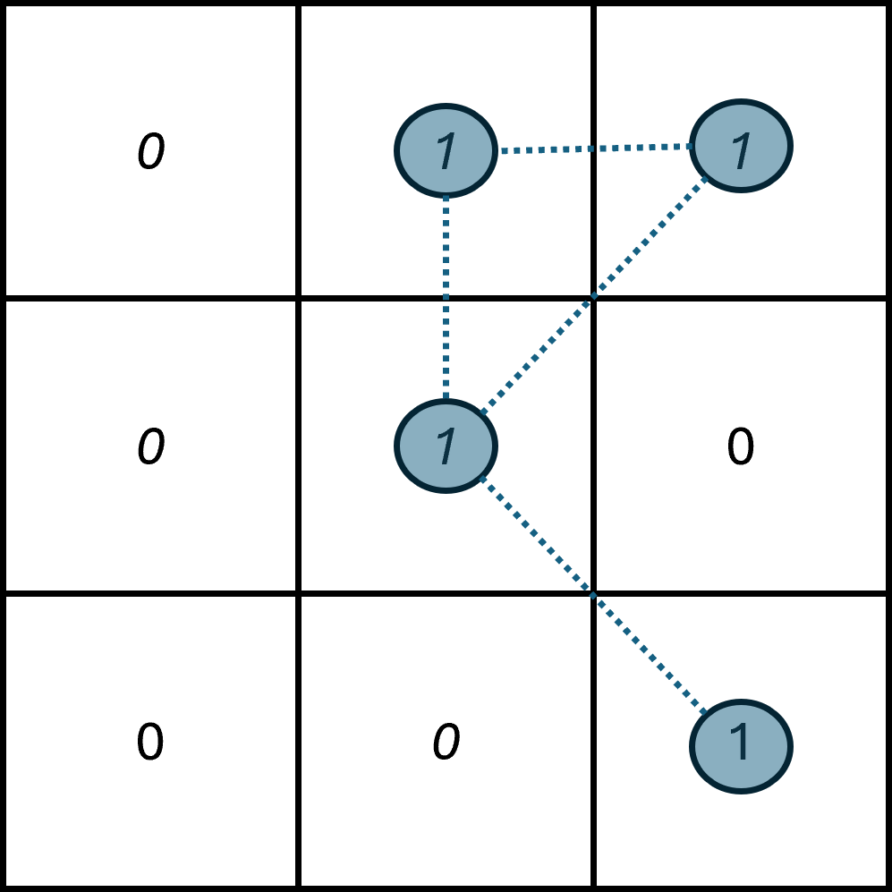

A8

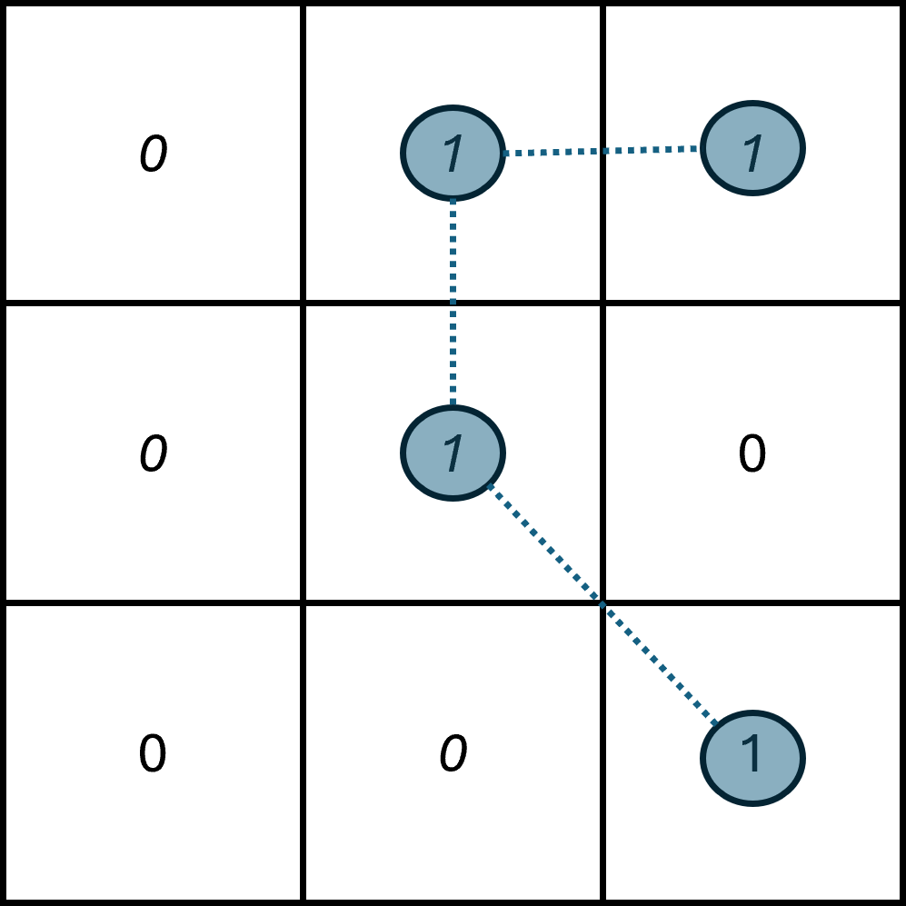

A-m

## Relationships between pixels – Path

**Digital path**

It is a sequence of adjacent pixels.

$$\left(x_0, y_0\right), \left(x_1, y_1\right), \left(x_2, y_2\right), \dots \left(x_n, y_n\right)$$

If $\left(x_0, y_0\right)=\left(x_n, y_n\right)$ the path is known as closed path

Let S represent a subset of pixels in an image. Two pixels p and q are said to be connected in S if there exists a path between them consisting entirely of pixels in S.

## Relationships between pixels – Path, Connected Subset

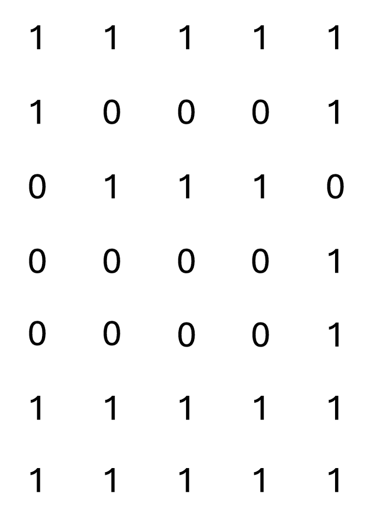

## Relationships between pixels – Regions

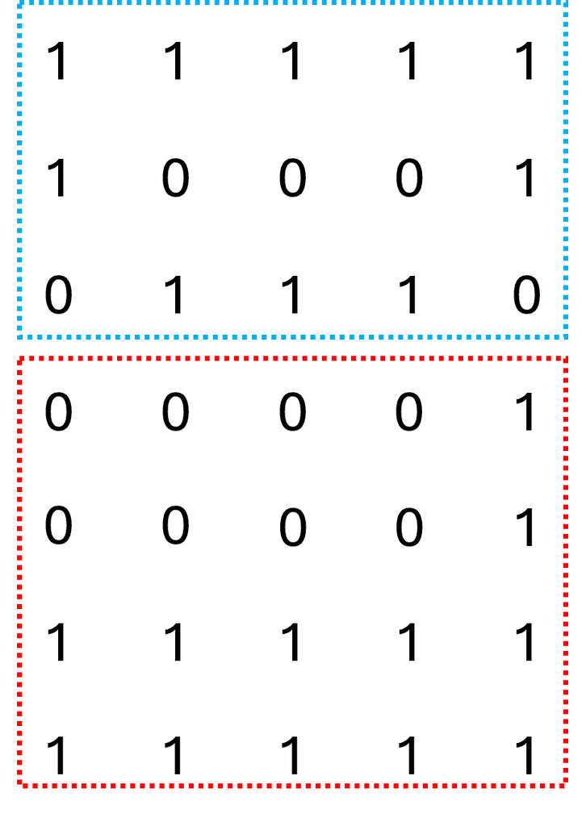

## Relationships between pixels – Boundary

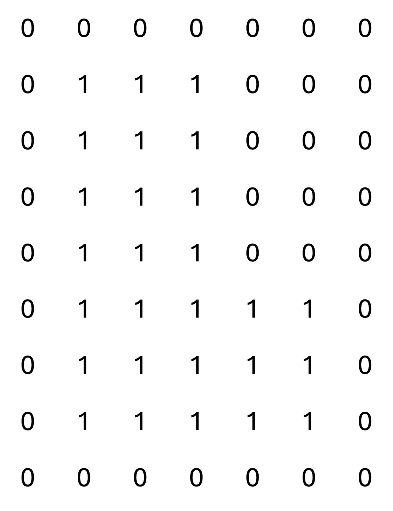

## Relationships between pixels – Distance

**Distance**

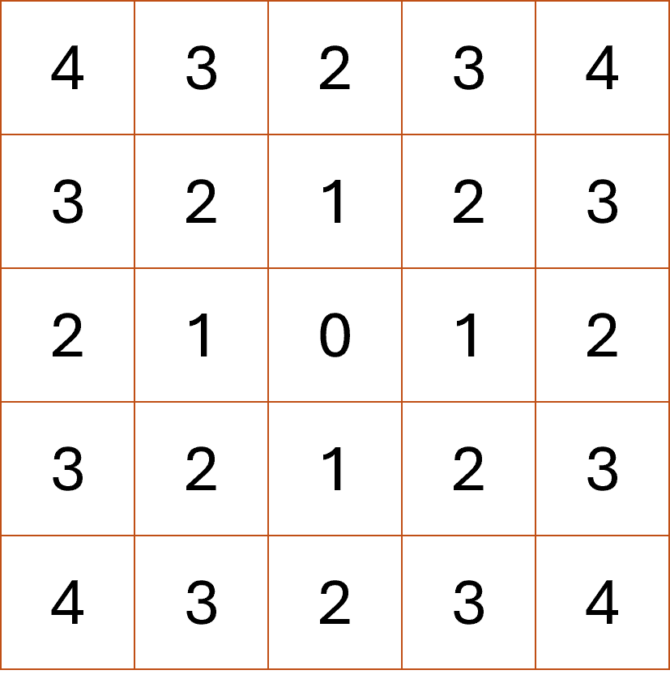

- **City block distance**: $D_4\left(p,q\right) = \lvert x-u\rvert + \lvert y-v \rvert$
- Chessboard distance: $D_8\left(p,q\right) = max \left(\lvert x-u\rvert , \lvert y-v \rvert \right)$
- Euclidean distance: $D_e\left(p,q\right) = \sqrt{\left(x-u\right)^2 + \left(y-v\right)^2}$

## Relationships between pixels

**Distance**

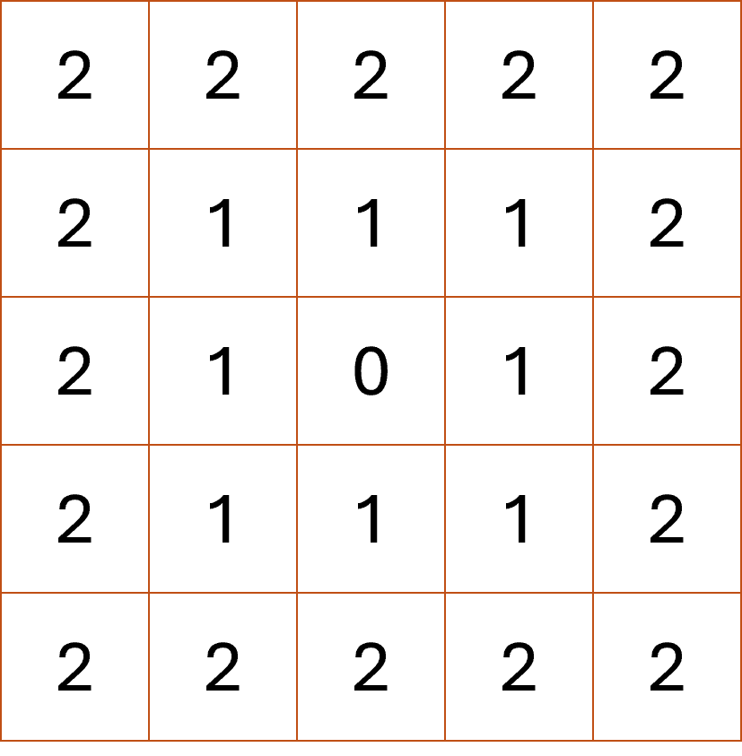

- City block distance: $D_4\left(p,q\right) = \lvert x-u\rvert + \lvert y-v \rvert$
- **Chessboard distance**: $D_8\left(p,q\right) = max \left(\lvert x-u\rvert , \lvert y-v \rvert \right)$
- Euclidean distance: $D_e\left(p,q\right) = \sqrt{\left(x-u\right)^2 + \left(y-v\right)^2}$

[figure not shown]

https://pacaicedo.github.io